# Les causes du retard et d'annulation des vols

## by Mariam COULIBALY

## Investigation Overview

Dans cette enquête, je voulais connaitre le pourcentage des vols annulés et detournés, la cause principale de retard et d'annulation des vols.La relation entre le retard de depart et d'arrivé.Le nombre d'annulation et de retards des vols par transporteurs.

## Dataset Overview

Cet ensemble de données se rapporte aux vols des États-Unis en 2008, y compris les transporteurs, les raisons de l'annulation des vols, les retards à l'arrivée et au départ, et les raisons des retards.Il contient 2.389.217 détails de vols (lignes) avec 29 caractéristiques(colonnes) y compris:ArrDelay, DepDelay, Cancelled, CancellationCode, CarrierDelay, WeatherDelay, NASDelay, SecurityDelay, LateAircraftDelay etc.La plupart des variables sont numériques, mais certaines sont catégorielles.

Un vol est considéré comme retardé si heure de départ/arrivée réelle est superieur à l'heure de départ/arrivée prévue. En d'autre terne si retard d'arrivée ou de départ est positive(supéieur à 0).

## Distribution de Cancelled, Diverted

on peut voir que **2.7%** des vols ont été annulé et seulement **0.2%** ont été detourné.

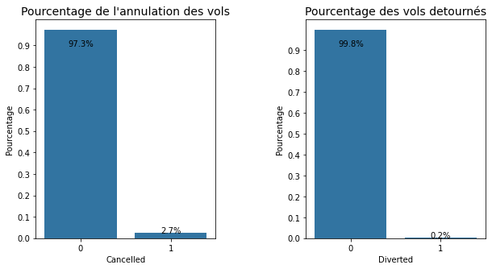

## Distribution du CancellationCode

La cause la plus fréquente d'annulation des vols est le **transporteur (A) soit 40.46%**, suivie de la **météo (B) soit 39.95%** et le **Système national d'espace aérien ou National Airspace System en anglais (C) soit 19.58%**. Il n'y a presque pas d'annulation des vols pour des raisons de **sécurité (D) soit 0.01%**.

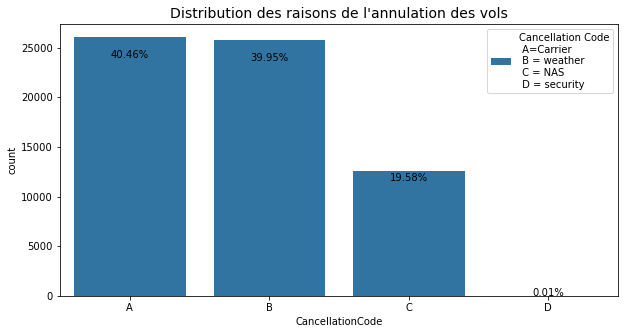

## Distribution du retard par causes

La cause principal du retard des vols est due au **LateAircraftDelay** soit **37.52%**, suivi du **NAS** ( Système national d'espace aérien ou National Airspace System en anglais) avec **28.90%**, suivi des **transporteurs (CarrierDelay) avec 28.18%** et les **conditions météorologique (WeatherDelay) avec 5.26%**.Il n'y a presque pas du retard des vols cause par la **sécurité(SecurityDelay) avec 0.14%**

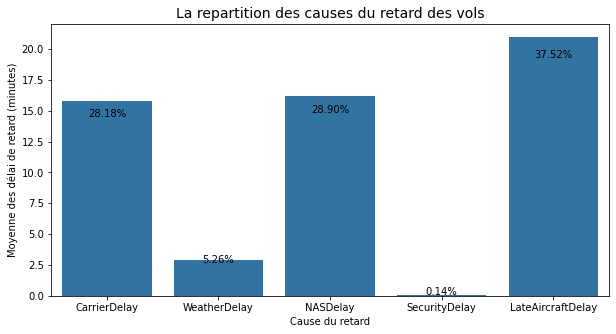

## ArrDelay vs. DepDelay

Il existe une forte correlation positive entre le retard du depart et à l'arrivée, ceci semble logique car un retard de depart va forcement entraine un retard à l'arrivé.

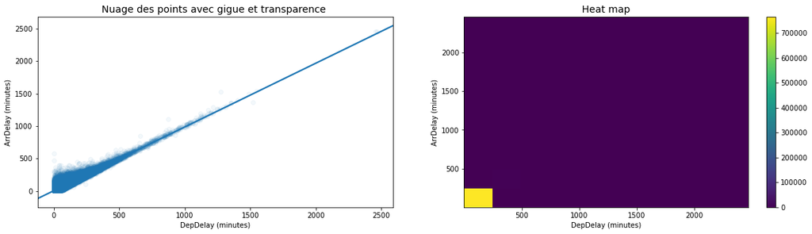

## UniqueCarrier vs. Cancelled

**AA** est le transporteur qui à fait le **maximum** d'annulation des vols, suivi **MQ, OO, YV et UA. AQ** est le transporteur qui à fait le minimum d'annulation des vols, suivi de **F9, HA, AS et B6**.

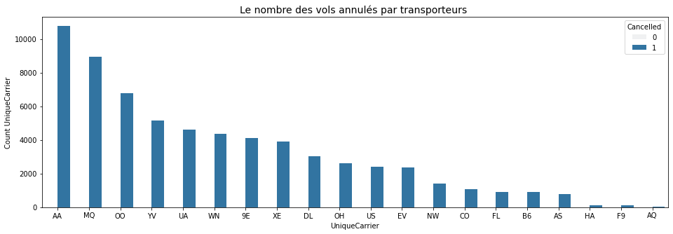

## UniqueCarrier vs.DepDelay & UniqueCarrier vs. ArrDelay

**YV** est le transporteur qui à fait le **maximum** de la moyenne de retard des vols au depart suivi de **B6, OH, 9E, UA. AQ** est le transporteur qui à fait le **minimum** de la moyenne de retard au depart des vols suivi de **HA, F9, WN, US**. **YV** est le transporteur qui à fait le **maximum** de la moyenne de retard des vols à l'arrivé suivi de **B6, UA, MQ,EV. AQ** est le transporteur qui à fait le **minimum** de la moyenne de retard des vols à l'arrivé suivi de **HA, F9, WN, DL**.

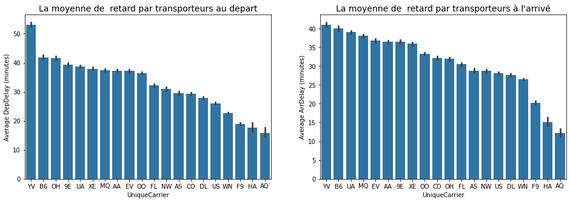